# PGS_Processing Notes

2025-04-23

# Introduction

This document serves as my notes for performing the updated PGS analyses on KPNC ACI. Previously, I set these scripts up to run on an HPC Cluster with a SLURM or torque scheduler, but that is not the computing infrastructure I am using at KPNC. Instead, I will be updating the code to run on simpler sessions of Rstudio and Linux.

Additionally, I will be picking up with the script `03_process_phenotype.R`. The scripts before this entail the processing of genotypes, PGS calculation, and PGS processing.

# Phenotype Processing

The goal of `03_process_phenotype.R` is to update the BMI, income, and education coding. After this, all the phenotypic information is joined to the genotype information in the PGS. It will then write one large phenotype file, individual phenotype files, and then one large phenotype file with the covariates. It then does all of these for the ancestry-specific information.

It looks like Ally already joined the PGS to the phenotype data in the files located at `/bd-fs-mnt/TenantShare/exthome/home/l578311/cvd/pgs_revised/data/final_cohorts/`.

# Pull PGS Outcomes

For the fourth script, I had to have Janise copy some additional files and folders from CCR to KPNC. This script updates some phenotype names and formats the PGS into PGS number rather than the trait name.

# Run PRSMix

I realized in this previous step that I was only using the phenotypic (STUDYIDs) and not the genotype information. I shared a Genotype map file with Janise, and changed the names in the phenotype to be the genotypic ID that is used for all the PGS information.

From here, I re-ran step `03_KPNC_process_phenotype.R` with a couple lines to update this. From there, I re-ran the `04` script. I then make `04_KPNC_call_ancestry_PRSMix.sh` which runs the analyses for all 5 groups in series.

The code appears to run without syntax or file errors, but I am getting the error:

```
Aggregating results
Something is wrong; all Accuracy metric vaues are missing:
```

Then all the values are NA or NaN. I discovered this because there are “2”s and “3”s coded in the phenotypes. When I revisited the data dictionary, Ally put these for when someone died before developing the phenotype (2) or had a prevalent phenotype at the time of diagnosis (3).

## Troubleshooting PRSMix

When I look through the log files, there are different errors that come up. For example, in `ALL_inc_dyslipid.log`, the error is:

```
Error in na.fail.default(list(trait = c(2L, 2L, 1L, 1L, 1L, 2L, 2L, 2L,  :
  missing values in object
Calls: combine_PRS ... model.frame.default -> <Anonymous> -> na.fail.default
Execution halted
```

When I check through these, I find that the lines 302-313 of the `combine_PRS` script where where the `train()` function is used may be causing the error.

Additionally, I find that in `EUR_inc_anycmd.log`, there is the different error:

```
Error in roc.default(response, predictor, ci = FALSE, ...) :
  Response and predictor must be vectors of the same length.
Calls: combine_PRS -> ci.auc -> ci.auc.default -> roc.default
In addition: Warning message:
In for (i in 1:length(args)) { :
  closing unused connection 4 (<-localhost:11988)
Execution halted
```

This may be from an error at line 320 of the `combine_PRS()` script.

Let’s start with the first error:

```r
covariate_file <- "/bd-fs-mnt/TenantShare/exthome/home/l578311/pgs_sandbox/phenotypes/ALL__covariates.txt"
basic_data = fread(covariate_file)

train_df <- fread("/bd-fs-mnt/TenantShare/exthome/home/l578311/prsmix_results/ALL_inc_dyslipid__train_df.txt", header = T)

cat_covar_list<- c("bl_inc_cat2", "bl_educlvl_5cat", "bl_meno_status", "smoke_status_6m", "prev_anycmd", "rad_tx_yn", "anthra_yn", "tras_yn", "horm_yn")
# Continuous variables (e.g., age, BMI, counts)
continuous_vars <- c( "dxage", "bmi_new",  "pc_util_count")

IID_pheno <- c("IID")

covar_list <- c(categorical_vars, continuous_vars)

basic_data = fread(covariate_file)
basic_data = basic_data[, c(IID_pheno, covar_list)]

basic_data <- basic_data %>% filter(!is.na(bmi_new))

train_tmp <- merge(train_df, basic_data, by="IID")

train_tmp$trait = as.factor(train_tmp$trait)
formula_null = as.formula(paste0("trait ~ ", paste0(covar_list,
  collapse = "+")))

nfold_cv = 3
ncores=1
ctrl = trainControl(method = "repeatedcv", allowParallel = TRUE,
  number = nfold_cv, returnData = FALSE, trim = T,
  verboseIter = T)
cl = makePSOCKcluster(ncores)
cl = makeCluster(ncores)
registerDoParallel(cl)
set.seed(123)
model_prsmix_null = train(formula_null, data = train_tmp,
  method = "glmnet", trControl = ctrl, family = "binomial",
  tuneLength = 50, verbose = T)


formula_null = as.formula(paste0("trait ~", paste0(covar_list, collapse = "+")))

model_prsmix_null = train(
  formula_null, data = train_tmp, method = "glmnet",
  trControl = ctrl, family = "binomial",
  tuneLength = 50, verbose = T
)
```

This was resolved by removing the `NA` from `bmi_new`. After resolving this error. The other error went away… But, a new one showed up:

In all the `inc_anycmd`, there is the issue:

```
--- Reading covariate data ---
Generating dummy variables from categorical variables
Error in top_vals$vals : $ operator is invalid for atomic vectors
Calls: combine_PRS ... make_dummy_columns -> dummy_cols -> <Anonymous> -> stri_order
In addition: Warning messages:
1: In max(vals$Freq) : no non-missing arguments to max; returning -Inf
2: In max(vals$Freq) : no non-missing arguments to max; returning -Inf
Execution halted
```

The issue above was addressed by fixing the phenotype file processing step. The prev_anycmd was being used for the inc_anycmd phenotype. This created issues because these individuals had to have no previous history.

# PRSMix Results

## Compare Accuracy

```r
pgs_dir<-"/bd-fs-mnt/TenantShare/exthome/home/l578311/"
file_directory <- "/bd-fs-mnt/TenantShare/exthome/home/l578311/prsmix_results"
file_list <- list.files(file_directory, pattern = "*_summary_traitPRS_withPRSmixPlus.txt", full.names = TRUE)
pheno_list <- c()

for (file in file_list) {
  phenotype <- sub(".*/(.*?)_power.0.95_pthres.0.00714285714285714_test_summary_traitPRS_withPRSmixPlus.txt", "\\1", file)
  pheno_list <- c(pheno_list, phenotype)
}

auc_pgs <- data.table()
auc_null <- data.table()
for (pheno in pheno_list){
  #AUC
  a_auc_pgs <- fread(pgs_dir %&% "prsmix_results/" %&% pheno %&% "_auc_BestPGS.txt", header = T)
  a_auc_pgs$pheno <- pheno
  a_auc_null <- fread(pgs_dir %&% "prsmix_results/" %&% pheno %&% "_auc_NULL.txt", header = T)
  a_auc_null$pheno <- pheno

  auc_pgs <- bind_rows(auc_pgs, a_auc_pgs)
  auc_null <- bind_rows(auc_null, a_auc_null)

  # ACCURACY


}
auc_comp <- bind_rows(auc_pgs, auc_null)
```

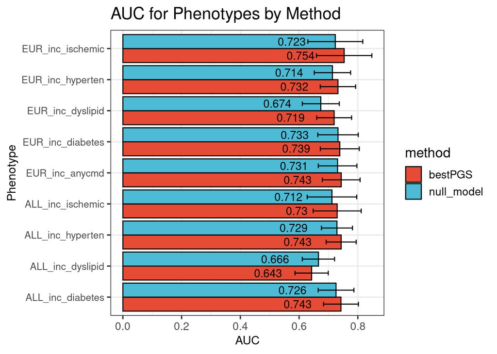

```r
ggplot(auc_comp, aes(x = auc, y = pheno, fill = method)) +
  geom_bar(stat = "identity", position = "dodge", color = "black") +  # Horizontal bars with borders
  geom_errorbar(aes(xmin = lowerCI, xmax = upperCI),
                width = 0.3,  # Width of the error bar ends
                position = position_dodge(width = 0.9)) +  # Dodge to align with bars
  geom_text(aes(label = round(auc, 3), x = auc - .1),  # Add labels slightly to the right
        position = position_dodge(width = 0.9),    # Align with bars
        size = 4,                                  # Adjust text size
        hjust = 1) +
  labs(
    x = "AUC",
    y = "Phenotype",
    title = "AUC for Phenotypes by Method"
  ) +
  theme_bw(14) +  # Clean theme
  theme(
    axis.text.y = element_text(size = 10),  # Adjust y-axis text size
    axis.title = element_text(size = 12),  # Adjust axis title size
    legend.position = "right"  # Place legend on the right
  ) +
  scale_fill_npg()
```

### Ancestry Specific

```r
pgs_dir <- "/bd-fs-mnt/TenantShare/exthome/home/l578311/"
file_directory <- "/bd-fs-mnt/TenantShare/exthome/home/l578311/prsmix_results"
file_list <- list.files(file_directory, pattern = "*_summary_traitPRS_withPRSmixPlus.txt", full.names = TRUE)
pheno_list <- c("inc_diabetes" ,"inc_dyslipid" ,"inc_ischemic", "inc_anycmd" , "inc_hyperten" )
#pheno_list <- c("inc_diabetes" ,"inc_dyslipid" ,"inc_ischemic" , "inc_hyperten" )


ANCESTRIES <- c("ALL",  "EUR", "AFR", "EAS", "AMR")

auc_pgs <- data.table()
auc_null <- data.table()
for(ancestry in ANCESTRIES){
  if(ancestry =="ALL"){
        for (pheno in pheno_list){
        #AUC
        a_auc_pgs <- fread(pgs_dir %&% "prsmix_results/" %&% ancestry %&% "_" %&% pheno %&% "_auc_BestPGS.txt", header = T)
        a_auc_pgs$pheno <- pheno
        a_auc_pgs$anc <- ancestry
        a_auc_null <- fread(pgs_dir %&% "prsmix_results/" %&% ancestry %&% "_" %&% pheno %&% "_auc_NULL.txt", header = T)
        a_auc_null$anc <- ancestry
        a_auc_null$pheno <- pheno

        auc_pgs <- bind_rows(auc_pgs, a_auc_pgs)
        auc_null <- bind_rows(auc_null, a_auc_null)
      }
    }else{
    for (pheno in pheno_list){
      #AUC
      a_auc_pgs <- fread(pgs_dir %&% "prsmix_results/" %&% ancestry %&% "_" %&% pheno %&% "_auc_BestPGS.txt", header = T)
      a_auc_pgs$pheno <- pheno
      a_auc_pgs$anc <- ancestry
      a_auc_null <- fread(pgs_dir %&% "prsmix_results/" %&% ancestry %&% "_" %&%  pheno %&% "_auc_NULL.txt", header = T)
      a_auc_null$anc <- ancestry
      a_auc_null$pheno <- pheno

      auc_pgs <- bind_rows(auc_pgs, a_auc_pgs)
      auc_null <- bind_rows(auc_null, a_auc_null)

    # ACCURACY
    }
  }
}


auc_comp <- bind_rows(auc_pgs, auc_null)
auc_comp$anc<-factor(auc_comp$anc, levels = c("ALL", "AFR", "AMR", "EAS", "EUR"))
```

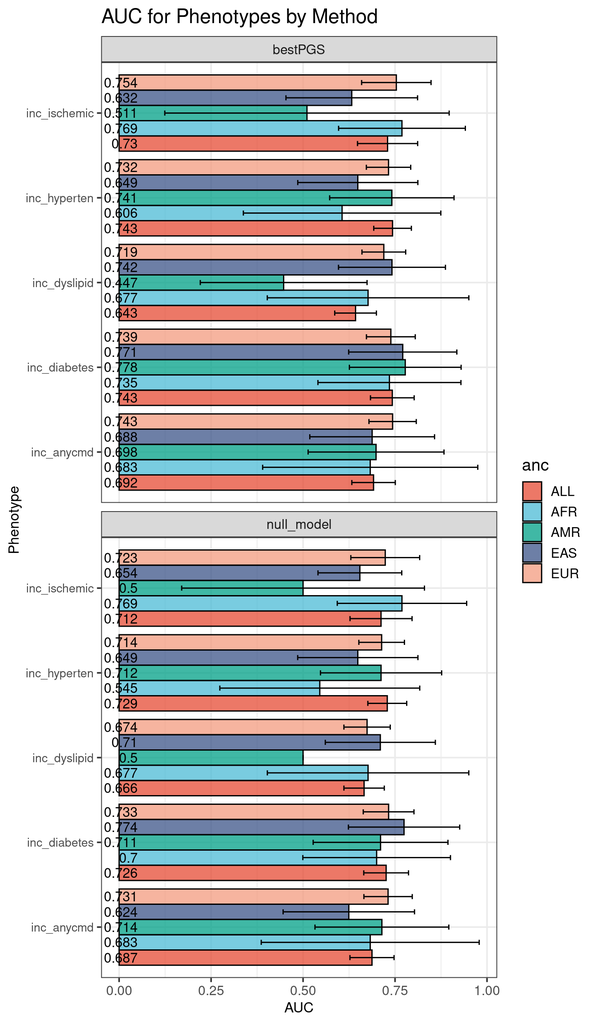

```r
ggplot(auc_comp, aes(x = auc, y = pheno, fill = anc)) +
  geom_bar(stat = "identity", position = "dodge", color = "black", alpha =0.75) +  # Horizontal bars with borders
  geom_errorbar(aes(xmin = lowerCI, xmax = upperCI),
                width = 0.3,  # Width of the error bar ends
                position = position_dodge(width = 0.9)) +  # Dodge to align with bars
  geom_text(aes(label = round(auc, 3), x = 0.05),  # Add labels slightly to the right
        position = position_dodge(width = 0.9),    # Align with bars
        size = 4,                                  # Adjust text size
        hjust = 1) +
  labs(
    x = "AUC",
    y = "Phenotype",
    title = "AUC for Phenotypes by Method"
  ) +
  theme_bw(14) +  # Clean theme
  theme(
    axis.text.y = element_text(size = 10),  # Adjust y-axis text size
    axis.title = element_text(size = 12),  # Adjust axis title size
    legend.position = "right"  # Place legend on the right
  ) +
  scale_fill_npg() + facet_wrap(~method, nrow=2)
```

# Pull difference in performance

```r
setDT(auc_comp)

# Check if there are both `bestPGS` and `null_model` methods for each group
if (all(c("bestPGS", "null_model") %in% unique(auc_comp$method))) {
  # Calculate the difference in AUC between bestPGS and null_model
  auc_differences <- auc_comp[
    , .(auc_diff = auc[method == "bestPGS"] - auc[method == "null_model"]),
    by = .(pheno, anc)
  ]

  # Print the results
  print(auc_differences)
} else {
  print("Both 'bestPGS' and 'null_model' must be present in the data for each group.")
}
```

```
##            pheno anc     auc_diff
##  1: inc_diabetes ALL  0.016784758
##  2: inc_dyslipid ALL -0.023196309
##  3: inc_ischemic ALL  0.017774433
##  4:   inc_anycmd ALL  0.004234388
##  5: inc_hyperten ALL  0.014333050
##  6: inc_diabetes EUR  0.006088372
##  7: inc_dyslipid EUR  0.045530726
##  8: inc_ischemic EUR  0.030116639
##  9:   inc_anycmd EUR  0.012345679
## 10: inc_hyperten EUR  0.018750000
## 11: inc_diabetes AFR  0.034782609
## 12: inc_dyslipid AFR  0.000000000
## 13: inc_ischemic AFR  0.000000000
## 14:   inc_anycmd AFR  0.000000000
## 15: inc_hyperten AFR  0.060606061
## 16: inc_diabetes EAS -0.003496503
## 17: inc_dyslipid EAS  0.031666667
## 18: inc_ischemic EAS -0.022058824
## 19:   inc_anycmd EAS  0.063492063
## 20: inc_hyperten EAS  0.000000000
## 21: inc_diabetes AMR  0.067129630
## 22: inc_dyslipid AMR -0.052727273
## 23: inc_ischemic AMR  0.010638298
## 24:   inc_anycmd AMR -0.015873016
## 25: inc_hyperten AMR  0.029333333
##            pheno anc     auc_diff
```

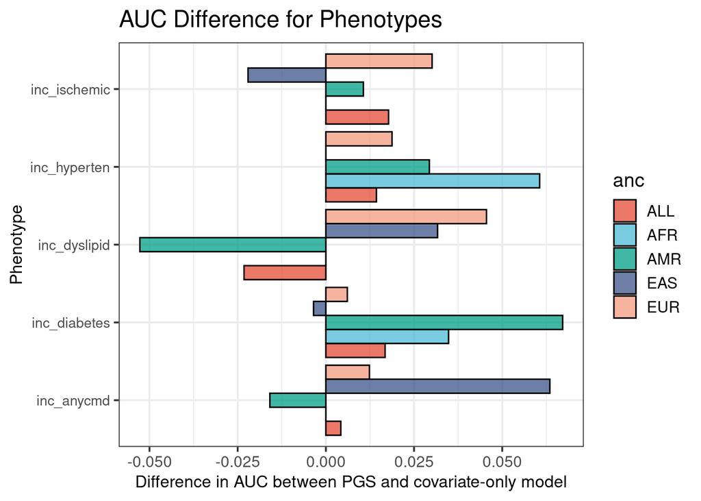

```r
ggplot(auc_differences, aes(x = auc_diff, y = pheno, fill = anc)) +
  geom_bar(stat = "identity", position = "dodge", color = "black", alpha =0.75) +  # Horizontal bars with borders
  labs(
    x = "Difference in AUC between PGS and covariate-only model",
    y = "Phenotype",
    title = "AUC Difference for Phenotypes"
  ) +
  theme_bw(14) +  # Clean theme
  theme(
    axis.text.y = element_text(size = 10),  # Adjust y-axis text size
    axis.title = element_text(size = 12),  # Adjust axis title size
    legend.position = "right"  # Place legend on the right
  ) +
  scale_fill_npg()
```

```r
file_directory <- "/bd-fs-mnt/TenantShare/exthome/home/l578311/prsmix_results"
file_list <- list.files(file_directory, pattern = "*_summary_traitPRS_withPRSmix.txt", full.names = TRUE)

prsmixplus_summary <- data.table()
for (file in file_list){
  phenotype <- sub(".*/(.*?)_power.0.95_pthres.0.00714285714285714_test_summary_traitPRS_withPRSmix.txt", "\\1", file)
  start <- fread(file)
  print("Processing: " %&% file)
  start$phenotype <- phenotype
  prsmixplus_summary <- bind_rows(prsmixplus_summary, start)
}
```

```
## [1] "Processing: /bd-fs-mnt/TenantShare/exthome/home/l578311/prsmix_results/ALL_inc_diabetes_power.0.95_pthres.0.00714285714285714_test_summary_traitPRS_withPRSmix.txt"
## [1] "Processing: /bd-fs-mnt/TenantShare/exthome/home/l578311/prsmix_results/ALL_inc_dyslipid_power.0.95_pthres.0.00714285714285714_test_summary_traitPRS_withPRSmix.txt"
## [1] "Processing: /bd-fs-mnt/TenantShare/exthome/home/l578311/prsmix_results/ALL_inc_hyperten_power.0.95_pthres.0.00714285714285714_test_summary_traitPRS_withPRSmix.txt"
## [1] "Processing: /bd-fs-mnt/TenantShare/exthome/home/l578311/prsmix_results/ALL_inc_ischemic_power.0.95_pthres.0.00714285714285714_test_summary_traitPRS_withPRSmix.txt"
## [1] "Processing: /bd-fs-mnt/TenantShare/exthome/home/l578311/prsmix_results/EUR_inc_anycmd_power.0.95_pthres.0.00714285714285714_test_summary_traitPRS_withPRSmix.txt"
## [1] "Processing: /bd-fs-mnt/TenantShare/exthome/home/l578311/prsmix_results/EUR_inc_diabetes_power.0.95_pthres.0.00714285714285714_test_summary_traitPRS_withPRSmix.txt"
## [1] "Processing: /bd-fs-mnt/TenantShare/exthome/home/l578311/prsmix_results/EUR_inc_dyslipid_power.0.95_pthres.0.00714285714285714_test_summary_traitPRS_withPRSmix.txt"
## [1] "Processing: /bd-fs-mnt/TenantShare/exthome/home/l578311/prsmix_results/EUR_inc_hyperten_power.0.95_pthres.0.00714285714285714_test_summary_traitPRS_withPRSmix.txt"
## [1] "Processing: /bd-fs-mnt/TenantShare/exthome/home/l578311/prsmix_results/EUR_inc_ischemic_power.0.95_pthres.0.00714285714285714_test_summary_traitPRS_withPRSmix.txt"
```

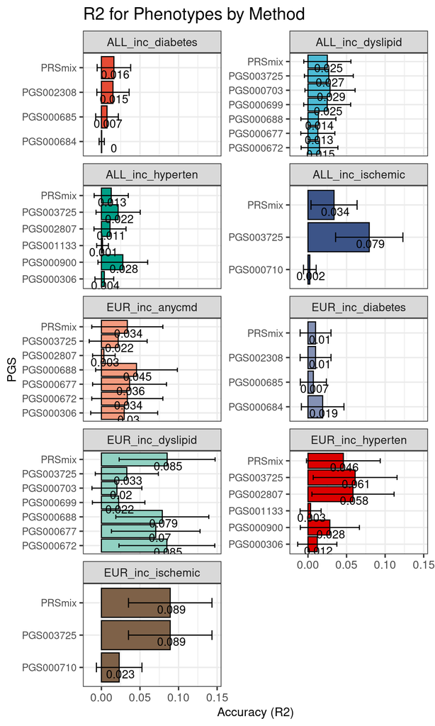

```r
ggplot(prsmixplus_summary, aes(x = R2, y = pgs, fill = phenotype)) +
  geom_bar(stat = "identity", position = "dodge", color = "black") +  # Horizontal bars with borders
  geom_errorbar(aes(xmin = lowerCI, xmax = upperCI),
                width = 0.3,  # Width of the error bar ends
                position = position_dodge(width = 0.9)) +  # Dodge to align with bars
  labs(
    x = "Accuracy (R2)",
    y = "PGS",
    title = "R2 for Phenotypes by Method"
  ) +
  theme_bw(14) +  # Clean theme
  theme(
    axis.text.y = element_text(size = 10),  # Adjust y-axis text size
    axis.title = element_text(size = 12),  # Adjust axis title size
    legend.position = "right"  # Place legend on the right
  ) +
  geom_text(aes(label = round(R2, 3), x = R2 + 0.02),  # Add labels slightly to the right
          position = position_dodge(width = 0.9),    # Align with bars
          size = 4,                                  # Adjust text size
          hjust = 1, vjust=1.3) +
  scale_fill_npg() + facet_wrap(~phenotype, scales = "free_y", nrow = 5) +guides(fill="none")
```